# Cell Identification

hongc2@ccf.org

1/16/2020

Load R variables worked in the previous step,

```r
library(data.table)
library(ggplot2)
library(Seurat)

load('filtered_gene_bc_matrices/hg19/02_pbmc3k_cluster.rd') #pbmc
load('filtered_gene_bc_matrices/hg19/03_pbmc3k_clusterAnalysis.rd') #pbmc.markers,top3,top10
```

We annotate cell types. The dataset was derived from PBMC sample. There are some marker genes. For cell ID, FACS sorting has been widely used.

### Assigning cell type identity in the cluster level

Fortunately, in the case of this dataset, we can use canonical markers to easily match the unbiased clustering to known cell types. The following table shows the marker genes expressed in each cluster and each marker is associated with known cell type.

| Cluster ID | Markers | Cell Type |
| --- | --- | --- |
| 0 | IL7R, CCR7 | Naive CD4+ T |
| 1 | CD14, LYZ | CD14+ Mono |
| 2 | IL7R, S100A4 | Memory CD4+ |
| 3 | CD8A | CD8+ T |
| 4 | MS4A1 | B |
| 5 | GNLY, NKG7 | NK |
| 6 | FCGR3A, MS4A7 | FCGR3A+ Mono |
| 7 | FCER1A, CST3 | DC |
| 8 | PPBP | Platelet |

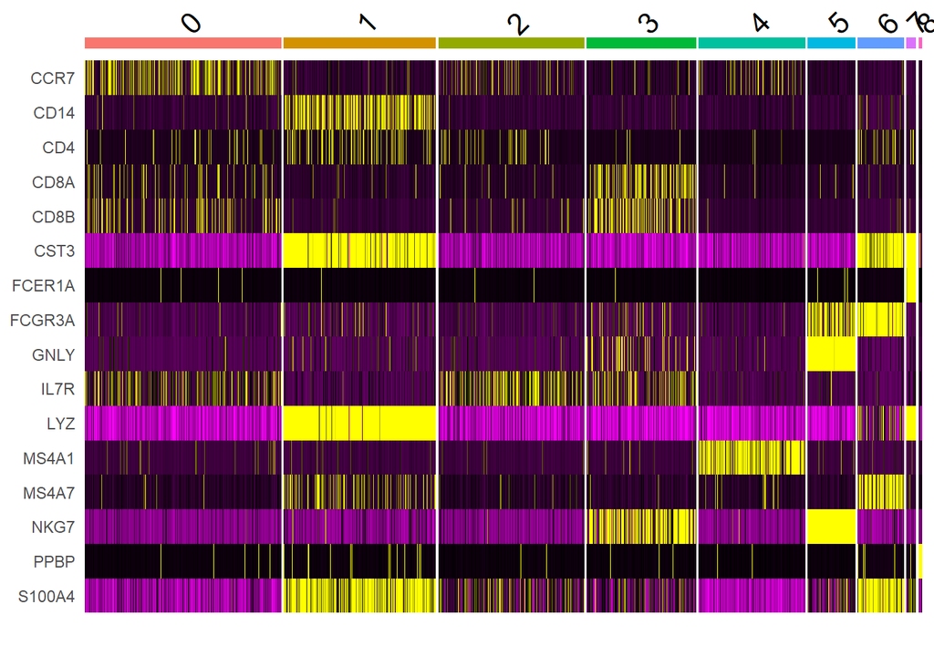

```r
marker_genes <- sort(c('IL7R','CD4','CCR7','S100A4','CD14','LYZ','MS4A1','CD8A','CD8B', 'FCGR3A','MS4A7','GNLY','NKG7','FCER1A','CST3','PPBP'))

DoHeatmap(pbmc, features = marker_genes) + NoLegend()
```

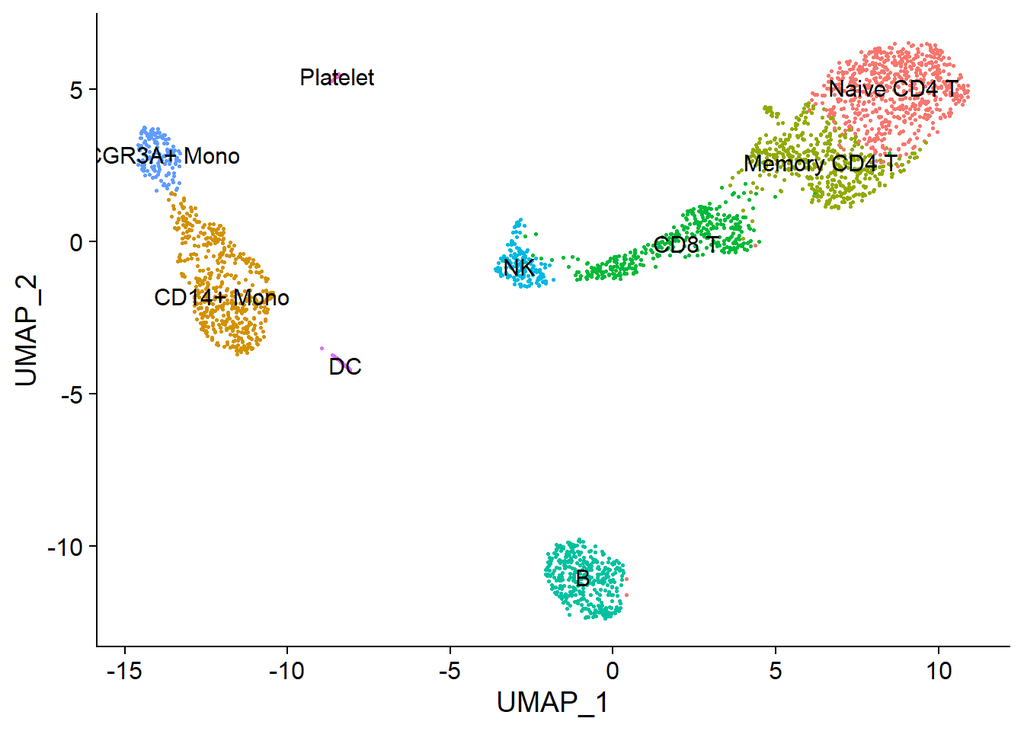

```r
# enumerate the cell type ID in the following order
new.cluster.ids <- c("Naive CD4 T", "CD14+ Mono","Memory CD4 T", "CD8 T","B", "NK", "FCGR3A+ Mono", "DC", "Platelet")

# assign name to each element
names(new.cluster.ids) <- levels(pbmc)

# add the cell type name and choose it as a cluster identity
pbmc <- RenameIdents(pbmc, new.cluster.ids)

# plot UMAP
DimPlot(pbmc,
        reduction = "umap",
        label = TRUE,
        pt.size = 0.5) + NoLegend()
```

### Assigning cell type identity to the cell level

The cluster is computationally assigned using highly variable genes. In practice, the marker genes may have little impact on clustering. Some cells may undergo the transition. Thus, it is more natural to assign the type at a cell level.

Here, we use the same gene markers above and predict the cell type for each cell with mRNA-based gene expression abundance. We will use [`SCINA`](https://www.mdpi.com/2073-4425/10/7/531) to perform this task.

*Task: Go to the developer [website](https://github.com/jcao89757/SCINA) and install the R package `SCINA`.*

**Answer**

```r
library("BiocManager")
BiocManager::install('SCINA')
```

Let us perform cell ID using the gene markers.

```r
library(SCINA)
markers <- preprocess.signatures('media/pbmc_simple.csv')
head(markers)
```

```
## $Naive_CD4_T
## [1] "IL7R" "CCR7"
##
## $Memory_CD4_T
## [1] "IL7R"   "S100A4" "LTB"
##
## $CD14_Mono
## [1] "CD14" "LYZ"  "CST3"
##
## $B
## [1] "MS4A1"
##
## $CD8_T
## [1] "CD8A"     "CD8B"     "low_CST3" "low_LYZ"
##
## $FCGR3A_Mono
## [1] "FCGR3A" "MS4A7"  "LST1"
```

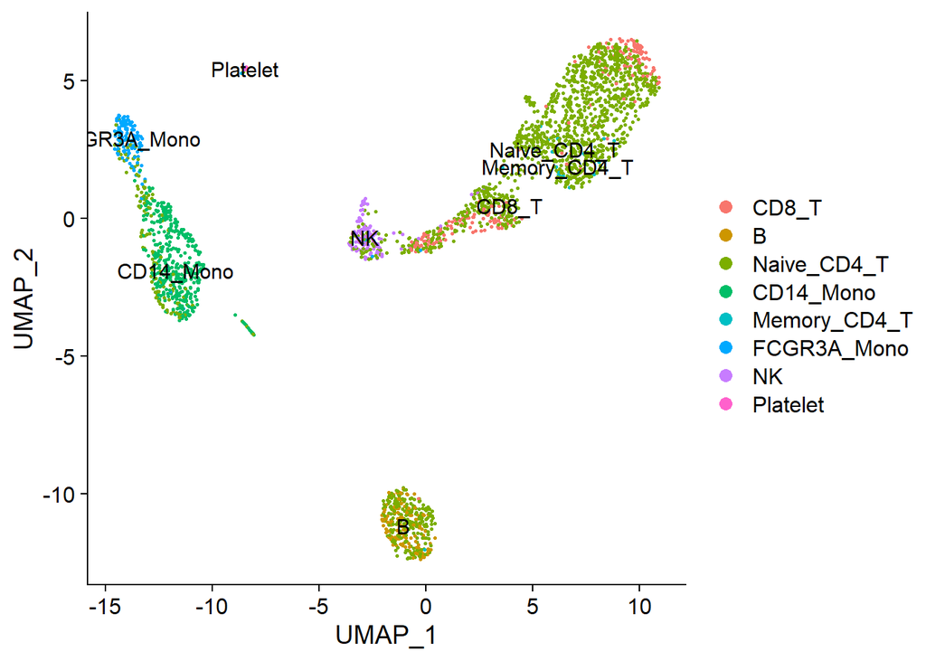

```r
pred_cell_ids <- SCINA(pbmc[["SCT"]]@counts,
                       markers,
                       max_iter = 100,
                       convergence_n = 10,
                       convergence_rate = 0.999,
                       sensitivity_cutoff = 0.9,
                       rm_overlap=FALSE,
                       allow_unknown=FALSE,
                       log_file='filtered_gene_bc_matrices/hg19/SCINA.log')

scina_field <- 'cellid_by_scina'

pbmc <- AddMetaData(object=pbmc,metadata=pred_cell_ids$cell_labels,col.name=scina_field)
Idents(pbmc) <- scina_field

DimPlot(pbmc,
        reduction = "umap",
        label = TRUE,
        pt.size = 0.5)
```

```r
# back to seurat_cluster
Idents(pbmc) <- "seurat_clusters"
```

Let us save the R variable so that we can contine to work.

```r
save(pbmc, file = "filtered_gene_bc_matrices/hg19/04_pbmc3k_cellid.Rmd",compress = TRUE)
```

### Assigning cell type identity by feature barcode

Recently, 10x Genomics provides [Feature Barcoding technology](https://support.10xgenomics.com/single-cell-gene-expression/software/pipelines/latest/using/feature-bc-analysis). A user chooses multiple antibodies. Both gene expression and suffice proteins shared the same cell barcode. We analyze each cell by profiling both gene expression and proteins at the cell suffice.

### Keep in mind

- What is cell-type identification?
- When cluster level cell type ID is useful?
- When cell level ID is useful?